# PYTHON FOR DATA ANALYSIS S220 COURSE OUTLINE

## 1. 2. 3. DESCRIPTIVE ANALYSIS Python essentials - Pandas - Matplotlib - Seaborn - Geopandas - Know your dataset

## 4. Webscraping

## 5.6.7.8. PREDICTIVE ANALYSIS

## 9. Releasing your work : API with Flask / Django

## 1. Four Python important concepts¶

( Many parts of this chapter are cut/paste of Romain Jouin Notebooks)

### 1.1 comprehension list

```python
import random
n     = 10
```

```python
une_chaine_de_caractere = "dsfghjklmsdfghjkldfghjklfdghjkl"
liste = []
for _ in range(n):
    caractere = random.choice(une_chaine_de_caractere)
    liste.append(caractere)
```

```python
liste
```

```
['l', 'g', 'f', 'h', 'm', 'd', 's', 'l', 'd', 'g']
```

```python
# [f(x) for x in sequence]

liste2 = [random.choice(une_chaine_de_caractere) for _ in range(n)]
liste2
```

```
['j', 's', 'k', 'k', 'l', 'j', 'l', 'l', 'j', 'h']
```

```python
liste2 = ["e" for _ in range(n)]
liste2
```

```
['e', 'e', 'e', 'e', 'e', 'e', 'e', 'e', 'e', 'e']
```

```python
liste2 = ["e"] * 10
liste2
```

```
['e', 'e', 'e', 'e', 'e', 'e', 'e', 'e', 'e', 'e']
```

```python
# [f(x) for x in sequence if condition]


liste2 = [ _ for _ in range(n) if _%2==0]
liste2
```

```
[0, 2, 4, 6, 8]
```

```python
# [f(x) if condition else g(x) for x in sequence]

liste2 = [ _ if _%2==0 else "impair" for _ in range(n) ]
liste2
```

```
[0, 'impair', 2, 'impair', 4, 'impair', 6, 'impair', 8, 'impair']
```

```python
# EQUIVAUT A

liste2=[]
def pairouimpair(x):
    if x%2==0:
        return x
    else:
        return "impair"
for i in range(n):
    liste2.append(pairouimpair(i))
liste2
```

```
[0, 'impair', 2, 'impair', 4, 'impair', 6, 'impair', 8, 'impair']
```

```python
liste2 = [ _ if _%2  else "pair" for _ in range(n) ]
liste2
```

```
['pair', 1, 'pair', 3, 'pair', 5, 'pair', 7, 'pair', 9]
```

```python
# Notez bien dans la cellule précédente le if _%2
# Qui équivaut à if _%2 != 0
# Car en python, tout ce qui n'est pas 0 est vrai
# Vérifions le :

if 0:
    print("0 est vrai")
else:
    print("0 est faux")
```

```
0 est faux
```

```python
if 1:
    print("1 est vrai")
else:
    print("1 est faux")
```

```
1 est vrai
```

```python
if "mldkfmslk":
    print("mldkfmslk est vrai")
else:
    print("mldkfmslk est faux")
```

```
mldkfmslk est vrai
```

```python
# valeur = lambda x:f(x)
valeur  = lambda param : param
```

```python
valeur("e")
```

```
'e'
```

```python
deux_fois  = lambda param : param*2
deux_fois("e")
```

```
'ee'
```

```python
# SAME THING AS
def deux_fois(x):
    return x*2

deux_fois("e")
```

```
'ee'
```

```python
deux_fois(["e"])
```

```
['e', 'e']
```

```python
deux_fois(deux_fois(["e"]))
```

```
['e', 'e', 'e', 'e']
```

```python
deux_fois(["1", "2"])
```

```
['1', '2', '1', '2']
```

```python
# LAMBDA DEFINED FUNCTION + LIST COMPREHENSION
zero_dixhuit = [deux_fois(_) for _ in range(10)]
zero_dixhuit
```

```
[0, 2, 4, 6, 8, 10, 12, 14, 16, 18]
```

```python
# DEFINE A FUNCTION
def asurb(a,b):
    return a/b

# Calling a function using ORDERERD PARAMETERS
# We must input the parameters in the same order used in function definition
asurb(10,2)
```

```
5.0
```

```python
# Calling a function using NAMED (aka Kewords) PARAMETERS
# Order don't matter anymore
asurb(b=10,a=20)
```

```
2.0
```

```python
# If we didn't gave default values for a parameter, we must transmit it when calling the function
asurb(b=10)
```

```
---------------------------------------------------------------------------
TypeError                                 Traceback (most recent call last)
<ipython-input-25-a40928b154e9> in <module>
      1 # If we didn't gave default values for a parameter, we must transmit it when calling the function
----> 2 asurb(b=10)

TypeError: asurb() missing 1 required positional argument: 'a'
```

```python
# DEFINE A FUNCTION  with DEFAULT VALUES
def asurb(a=10,b=5):
    return a/b
```

```python
asurb(b=10)
```

```
1.0
```

```python
asurb()
```

```
2.0
```

```python
# FIRST LET'S CREATE A RANDOM DATAFRAME

import random
import pandas as pd
eleves=['William','Hugh','Marvin','Stella','Serge','Kimiko']
# LIST COMPREHENSION
liste_eleves = [random.choice(eleves) for _ in range(60)]

# as we saw before, this is EQUIVALENT TO
# liste_eleves=[]
# for _ in range(60):
#    liste_eleves.append(random.choice(eleves))

def note():
    return(random.randint(1,20))

notes = [ note() for _ in range(60)]

eleves_notes = pd.DataFrame()
eleves_notes['eleve']=liste_eleves
eleves_notes['note']=notes
eleves_notes
```

|  | eleve | note |
| --- | --- | --- |
| 0 | Serge | 2 |
| 1 | Kimiko | 18 |
| 2 | Stella | 1 |
| 3 | Hugh | 17 |
| 4 | Serge | 12 |
| 5 | Serge | 9 |
| 6 | Marvin | 4 |
| 7 | Stella | 11 |
| 8 | Serge | 17 |
| 9 | Serge | 19 |
| 10 | Marvin | 16 |
| 11 | Stella | 14 |
| 12 | Stella | 20 |
| 13 | Kimiko | 10 |
| 14 | William | 19 |
| 15 | Stella | 7 |
| 16 | William | 7 |
| 17 | William | 16 |
| 18 | William | 7 |
| 19 | Kimiko | 11 |
| 20 | Serge | 18 |
| 21 | Hugh | 2 |
| 22 | Kimiko | 4 |
| 23 | Marvin | 18 |
| 24 | Serge | 7 |
| 25 | Serge | 16 |
| 26 | Kimiko | 18 |
| 27 | Kimiko | 18 |
| 28 | Serge | 17 |
| 29 | William | 14 |
| 30 | Hugh | 18 |
| 31 | Hugh | 15 |
| 32 | William | 8 |
| 33 | William | 8 |
| 34 | William | 1 |
| 35 | Hugh | 8 |
| 36 | Hugh | 13 |
| 37 | Marvin | 17 |
| 38 | William | 3 |
| 39 | Stella | 16 |
| 40 | Hugh | 3 |
| 41 | Hugh | 5 |
| 42 | William | 9 |
| 43 | Kimiko | 8 |
| 44 | Hugh | 5 |
| 45 | William | 9 |
| 46 | Stella | 17 |
| 47 | Hugh | 16 |
| 48 | William | 5 |
| 49 | Marvin | 8 |
| 50 | Marvin | 17 |
| 51 | William | 11 |
| 52 | William | 17 |
| 53 | Kimiko | 15 |
| 54 | Marvin | 20 |
| 55 | Marvin | 10 |
| 56 | Stella | 13 |
| 57 | Marvin | 17 |
| 58 | Stella | 15 |
| 59 | Hugh | 7 |

```python
# Like we did last TP, let's create a function to extract the best 5 grades for each student

def get_top5(df):
    return df.sort_values(by="note")[-5:]

# rank here is static, it cannot be transmitted during the function call

eleves_notes.groupby(['eleve']).apply(get_top5)
```

| eleve |  | eleve | note |
| --- | --- | --- | --- |
| Hugh | 36 | Hugh | 13 |
|  | 31 | Hugh | 15 |
|  | 47 | Hugh | 16 |
|  | 3 | Hugh | 17 |
|  | 30 | Hugh | 18 |
| Kimiko | 19 | Kimiko | 11 |
|  | 53 | Kimiko | 15 |
|  | 1 | Kimiko | 18 |
|  | 26 | Kimiko | 18 |
|  | 27 | Kimiko | 18 |
| Marvin | 37 | Marvin | 17 |
|  | 50 | Marvin | 17 |
|  | 57 | Marvin | 17 |
|  | 23 | Marvin | 18 |
|  | 54 | Marvin | 20 |
| Serge | 25 | Serge | 16 |
|  | 8 | Serge | 17 |
|  | 28 | Serge | 17 |
|  | 20 | Serge | 18 |
|  | 9 | Serge | 19 |
| Stella | 11 | Stella | 14 |
|  | 58 | Stella | 15 |
|  | 39 | Stella | 16 |
|  | 46 | Stella | 17 |
|  | 12 | Stella | 20 |
| William | 51 | William | 11 |
|  | 29 | William | 14 |
|  | 17 | William | 16 |
|  | 52 | William | 17 |
|  | 14 | William | 19 |

```python
# During last TP, a student proposed this method :
# **kwags will create a dict with all the named parameters

def get_top(df,**kwags):
    return df.sort_values(by="note")[-kwags['top']:]

eleves_notes.groupby(['eleve']).apply(get_top,top=5)
```

| eleve |  | eleve | note |
| --- | --- | --- | --- |
| Hugh | 36 | Hugh | 13 |
|  | 31 | Hugh | 15 |
|  | 47 | Hugh | 16 |
|  | 3 | Hugh | 17 |
|  | 30 | Hugh | 18 |
| Kimiko | 19 | Kimiko | 11 |
|  | 53 | Kimiko | 15 |
|  | 1 | Kimiko | 18 |
|  | 26 | Kimiko | 18 |
|  | 27 | Kimiko | 18 |
| Marvin | 37 | Marvin | 17 |
|  | 50 | Marvin | 17 |
|  | 57 | Marvin | 17 |
|  | 23 | Marvin | 18 |
|  | 54 | Marvin | 20 |
| Serge | 25 | Serge | 16 |
|  | 8 | Serge | 17 |
|  | 28 | Serge | 17 |
|  | 20 | Serge | 18 |
|  | 9 | Serge | 19 |
| Stella | 11 | Stella | 14 |
|  | 58 | Stella | 15 |
|  | 39 | Stella | 16 |
|  | 46 | Stella | 17 |
|  | 12 | Stella | 20 |
| William | 51 | William | 11 |
|  | 29 | William | 14 |
|  | 17 | William | 16 |
|  | 52 | William | 17 |
|  | 14 | William | 19 |

```python
# please note that kwags name is not mandatory
# the only mandatory element is the double * (splats) for "packing"
# Here we add the sort column name as a parameter.

def get_top(df,**mondicoamoi):
    return df.sort_values(by=mondicoamoi['sort'])[-mondicoamoi['top']:]

eleves_notes.groupby(['eleve']).apply(get_top,sort="note",top=3)
```

| eleve |  | eleve | note |
| --- | --- | --- | --- |
| Hugh | 47 | Hugh | 16 |
|  | 3 | Hugh | 17 |
|  | 30 | Hugh | 18 |
| Kimiko | 1 | Kimiko | 18 |
|  | 26 | Kimiko | 18 |
|  | 27 | Kimiko | 18 |
| Marvin | 57 | Marvin | 17 |
|  | 23 | Marvin | 18 |
|  | 54 | Marvin | 20 |
| Serge | 28 | Serge | 17 |
|  | 20 | Serge | 18 |
|  | 9 | Serge | 19 |
| Stella | 39 | Stella | 16 |
|  | 46 | Stella | 17 |
|  | 12 | Stella | 20 |
| William | 17 | William | 16 |
|  | 52 | William | 17 |
|  | 14 | William | 19 |

```python
# But we can do more simple ( and add sort column as parameter) :

def get_top(df,top,sort):
    return df.sort_values(by=sort)[-top:]

eleves_notes.groupby(['eleve']).apply(get_top,sort="note",top=2)
```

| eleve |  | eleve | note |
| --- | --- | --- | --- |
| Hugh | 3 | Hugh | 17 |
|  | 30 | Hugh | 18 |
| Kimiko | 26 | Kimiko | 18 |
|  | 27 | Kimiko | 18 |
| Marvin | 23 | Marvin | 18 |
|  | 54 | Marvin | 20 |
| Serge | 20 | Serge | 18 |
|  | 9 | Serge | 19 |
| Stella | 46 | Stella | 17 |
|  | 12 | Stella | 20 |
| William | 52 | William | 17 |
|  | 14 | William | 19 |

```python
# And give default values

def get_top(df,top=10,sort='note'):
    return df.sort_values(by=sort)[-top:]

eleves_notes.groupby(['eleve']).apply(get_top,top=2)
```

| eleve |  | eleve | note |
| --- | --- | --- | --- |
| Hugh | 3 | Hugh | 17 |
|  | 30 | Hugh | 18 |
| Kimiko | 26 | Kimiko | 18 |
|  | 27 | Kimiko | 18 |
| Marvin | 23 | Marvin | 18 |
|  | 54 | Marvin | 20 |
| Serge | 20 | Serge | 18 |
|  | 9 | Serge | 19 |
| Stella | 46 | Stella | 17 |
|  | 12 | Stella | 20 |
| William | 52 | William | 17 |
|  | 14 | William | 19 |

```python
!pip install wheel
!pip install pipwin

!pipwin install numpy
!pipwin install pandas
!pipwin install shapely
!pipwin install gdal
!pipwin install fiona
!pipwin install pyproj
!pipwin install six
!pipwin install rtree
!pipwin install geopandas
```

```
Package `numpy` found in cache
Downloading package . . .
https://download.lfd.uci.edu/pythonlibs/x2tqcw5k/numpy-1.19.2+mkl-cp38-cp38-win_amd64.whl
numpy-1.19.2+mkl-cp38-cp38-win_amd64.whl
```

[output not shown]

```
Package `pandas` found in cache
Downloading package . . .
https://download.lfd.uci.edu/pythonlibs/x2tqcw5k/pandas-1.1.3-cp38-cp38-win_amd64.whl
pandas-1.1.3-cp38-cp38-win_amd64.whl
```

[output not shown]

```
Package `shapely` found in cache
Downloading package . . .
https://download.lfd.uci.edu/pythonlibs/x2tqcw5k/Shapely-1.7.1-cp38-cp38-win_amd64.whl
Shapely-1.7.1-cp38-cp38-win_amd64.whl
```

[output not shown]

```
Package `gdal` found in cache
Downloading package . . .
https://download.lfd.uci.edu/pythonlibs/x2tqcw5k/GDAL-3.1.3-cp38-cp38-win_amd64.whl
GDAL-3.1.3-cp38-cp38-win_amd64.whl
```

[output not shown]

```
Package `fiona` found in cache
Downloading package . . .
https://download.lfd.uci.edu/pythonlibs/x2tqcw5k/Fiona-1.8.17-cp38-cp38-win_amd64.whl
Fiona-1.8.17-cp38-cp38-win_amd64.whl
```

[output not shown]

```
Package `pyproj` found in cache
Downloading package . . .
https://download.lfd.uci.edu/pythonlibs/x2tqcw5k/pyproj-2.6.1.post1-cp38-cp38-win_amd64.whl
pyproj-2.6.1.post1-cp38-cp38-win_amd64.whl
```

[output not shown]

```
Package `six` found in cache
Downloading package . . .
https://download.lfd.uci.edu/pythonlibs/x2tqcw5k/six-1.15.0-py3-none-any.whl
six-1.15.0-py3-none-any.whl
```

[output not shown]

```
Package `rtree` found in cache
Downloading package . . .
https://download.lfd.uci.edu/pythonlibs/x2tqcw5k/Rtree-0.9.4-cp38-cp38-win_amd64.whl
Rtree-0.9.4-cp38-cp38-win_amd64.whl
```

[output not shown]

```
Package `geopandas` found in cache
Downloading package . . .
https://download.lfd.uci.edu/pythonlibs/x2tqcw5k/geopandas-0.8.1-py3-none-any.whl
geopandas-0.8.1-py3-none-any.whl
```

[output not shown]

```python
import sys
path = fr"{str(sys.executable)}"
get_ipython().system('"{path}" -m pip install geopandas --user')
```

```python
import geopandas as gpd
map_df = gpd.read_file("dataset/departements-20140306-5m-shp/departements-20140306-5m.shp")
map_df
```

|  | code_insee | nom | nuts3 | wikipedia | geometry |
| --- | --- | --- | --- | --- | --- |
| 0 | 01 | Ain | FR711 | b'fr:Ain (d\xe9partement)' | POLYGON ((5.25559 45.78459, 5.24813 45.78176, ... |
| 1 | 02 | Aisne | FR221 | b'fr:Aisne (d\xe9partement)' | POLYGON ((3.48175 48.86640, 3.48144 48.86635, ... |
| 2 | 03 | Allier | FR721 | b'fr:Allier (d\xe9partement)' | POLYGON ((2.38613 46.33196, 2.38597 46.33203, ... |
| 3 | 04 | Alpes-de-Haute-Provence | FR821 | fr:Alpes-de-Haute-Provence | POLYGON ((6.66579 43.83120, 6.66739 43.83119, ... |
| 4 | 05 | Hautes-Alpes | FR822 | fr:Hautes-Alpes | POLYGON ((6.24158 44.44686, 6.24210 44.44732, ... |
| ... | ... | ... | ... | ... | ... |
| 96 | 971 | Guadeloupe | FR910 | fr:Guadeloupe | MULTIPOLYGON (((-61.61403 15.83955, -61.61399 ... |
| 97 | 972 | Martinique | FR920 | fr:Martinique | MULTIPOLYGON (((-60.86880 14.39091, -60.86875 ... |
| 98 | 973 | Guyane | FR930 | fr:Guyane | MULTIPOLYGON (((-52.58463 5.28309, -52.58348 5... |
| 99 | 974 | b'La R\xe9union' | FR940 | b'fr:La R\xe9union' | MULTIPOLYGON (((55.77886 -21.36291, 55.77889 -... |
| 100 | 976 | Mayotte | None | fr:Mayotte | MULTIPOLYGON (((45.13667 -13.00398, 45.13690 -... |

101 rows × 5 columns

```python
pip install descartes
```

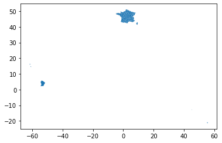

```python
import matplotlib as plt
%matplotlib inline
map_df.plot()
```

```python
# map_df[map_df.code_insee.str.contains("\d\d\d")==True] \d un chiffre de 0 à 9
map_df[map_df.code_insee.str.contains("\d\d\d")]
```

|  | code_insee | nom | nuts3 | wikipedia | geometry |
| --- | --- | --- | --- | --- | --- |
| 96 | 971 | Guadeloupe | FR910 | fr:Guadeloupe | MULTIPOLYGON (((-61.61403 15.83955, -61.61399 ... |
| 97 | 972 | Martinique | FR920 | fr:Martinique | MULTIPOLYGON (((-60.86880 14.39091, -60.86875 ... |
| 98 | 973 | Guyane | FR930 | fr:Guyane | MULTIPOLYGON (((-52.58463 5.28309, -52.58348 5... |
| 99 | 974 | b'La R\xe9union' | FR940 | b'fr:La R\xe9union' | MULTIPOLYGON (((55.77886 -21.36291, 55.77889 -... |
| 100 | 976 | Mayotte | None | fr:Mayotte | MULTIPOLYGON (((45.13667 -13.00398, 45.13690 -... |

```python
# LET'S SEPARATE DOM TOM FROM MAINLAND USING contains and REGEXP syntax
map_df=map_df[map_df.code_insee.str.contains("\d\d\d")==False]

# FILTER SYNTAX FOUND HERE : https://cmdlinetips.com/2018/02/how-to-subset-pandas-dataframe-based-on-values-of-a-column
```

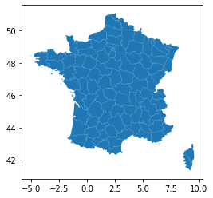

```python
map_df.plot()
```

```python
map_df
```

|  | code_insee | nom | nuts3 | wikipedia | geometry |
| --- | --- | --- | --- | --- | --- |
| 0 | 01 | Ain | FR711 | b'fr:Ain (d\xe9partement)' | POLYGON ((5.25559 45.78459, 5.24813 45.78176, ... |
| 1 | 02 | Aisne | FR221 | b'fr:Aisne (d\xe9partement)' | POLYGON ((3.48175 48.86640, 3.48144 48.86635, ... |
| 2 | 03 | Allier | FR721 | b'fr:Allier (d\xe9partement)' | POLYGON ((2.38613 46.33196, 2.38597 46.33203, ... |
| 3 | 04 | Alpes-de-Haute-Provence | FR821 | fr:Alpes-de-Haute-Provence | POLYGON ((6.66579 43.83120, 6.66739 43.83119, ... |
| 4 | 05 | Hautes-Alpes | FR822 | fr:Hautes-Alpes | POLYGON ((6.24158 44.44686, 6.24210 44.44732, ... |
| ... | ... | ... | ... | ... | ... |
| 91 | 91 | Essonne | FR104 | b'fr:Essonne (d\xe9partement)' | POLYGON ((2.39233 48.33593, 2.39382 48.33444, ... |
| 92 | 92 | Hauts-de-Seine | FR105 | fr:Hauts-de-Seine | POLYGON ((2.31993 48.77075, 2.31786 48.76867, ... |
| 93 | 93 | Seine-Saint-Denis | FR106 | fr:Seine-Saint-Denis | POLYGON ((2.41899 48.84939, 2.41636 48.84924, ... |
| 94 | 94 | Val-de-Marne | FR107 | fr:Val-de-Marne | POLYGON ((2.41450 48.71780, 2.41320 48.71868, ... |
| 95 | 95 | Val-d'Oise | FR108 | fr:Val-d'Oise | POLYGON ((1.79674 49.07196, 1.79719 49.07144, ... |

96 rows × 5 columns

```python
# YOU MUST KNOW REGEXPS
# REGEXP SYNTAX https://www.w3schools.com/python/python_regex.asp
# Pandas contains :
```

```python
# GEOPANDAS MERGE (JOIN)
# https://geopandas.org/mergingdata.html

# Now that we have our shape map containing a dataframe with
# - a column containing polygon definition
# - a column with departments codes
# We need to make a join with our firstname dataframe

prenoms= pd.read_csv("dataset/prenoms_fr_1900_2018_insee.csv",sep=";")
prenoms
```

|  | sexe | preusuel | annais | dpt | nombre |
| --- | --- | --- | --- | --- | --- |
| 0 | 1 | _PRENOMS_RARES | 1900 | 02 | 7 |
| 1 | 1 | _PRENOMS_RARES | 1900 | 04 | 9 |
| 2 | 1 | _PRENOMS_RARES | 1900 | 05 | 8 |
| 3 | 1 | _PRENOMS_RARES | 1900 | 06 | 23 |
| 4 | 1 | _PRENOMS_RARES | 1900 | 07 | 9 |
| ... | ... | ... | ... | ... | ... |
| 3676677 | 2 | ZYA | 2018 | 59 | 3 |
| 3676678 | 2 | ZYA | XXXX | XX | 252 |
| 3676679 | 2 | ZYNA | 2013 | 93 | 3 |
| 3676680 | 2 | ZYNA | XXXX | XX | 54 |
| 3676681 | 2 | ZYNEB | XXXX | XX | 111 |

3676682 rows × 5 columns

```python
dpt_sum=prenoms.groupby("dpt").nombre.sum()
dpt_sum #Une series une liste à une dimension
```

```
dpt
01      440132
02      845825
03      500158
04      106020
05      126691
        ...
971     643111
972     639827
973     174634
974    1201566
XX     8465506
Name: nombre, Length: 100, dtype: int64
```

```python
type(dpt_sum)
```

```
pandas.core.series.Series
```

```python
# We want a dataframe to do the merging
dpt_sum=dpt_sum.reset_index()
dpt_sum
```

|  | dpt | nombre |
| --- | --- | --- |
| 0 | 01 | 440132 |
| 1 | 02 | 845825 |
| 2 | 03 | 500158 |
| 3 | 04 | 106020 |
| 4 | 05 | 126691 |
| ... | ... | ... |
| 95 | 971 | 643111 |
| 96 | 972 | 639827 |
| 97 | 973 | 174634 |
| 98 | 974 | 1201566 |
| 99 | XX | 8465506 |

100 rows × 2 columns

```python
type(dpt_sum)
```

```
pandas.core.frame.DataFrame
```

```python
# Let's create a new department column with the same name than the column in our shape file
dpt_sum["code_insee"]=dpt_sum.dpt
```

```python
dpt_sum
```

|  | dpt | nombre | code_insee |
| --- | --- | --- | --- |
| 0 | 01 | 440132 | 01 |
| 1 | 02 | 845825 | 02 |
| 2 | 03 | 500158 | 03 |
| 3 | 04 | 106020 | 04 |
| 4 | 05 | 126691 | 05 |
| ... | ... | ... | ... |
| 95 | 971 | 643111 | 971 |
| 96 | 972 | 639827 | 972 |
| 97 | 973 | 174634 | 973 |
| 98 | 974 | 1201566 | 974 |
| 99 | XX | 8465506 | XX |

100 rows × 3 columns

```python
# NOW LET'S MAKE THE MERGE


merged = map_df.merge(dpt_sum, on='code_insee')

merged.head()

merged
```

|  | code_insee | nom | nuts3 | wikipedia | geometry | dpt | nombre |
| --- | --- | --- | --- | --- | --- | --- | --- |
| 0 | 01 | Ain | FR711 | b'fr:Ain (d\xe9partement)' | POLYGON ((5.25559 45.78459, 5.24813 45.78176, ... | 01 | 440132 |
| 1 | 02 | Aisne | FR221 | b'fr:Aisne (d\xe9partement)' | POLYGON ((3.48175 48.86640, 3.48144 48.86635, ... | 02 | 845825 |
| 2 | 03 | Allier | FR721 | b'fr:Allier (d\xe9partement)' | POLYGON ((2.38613 46.33196, 2.38597 46.33203, ... | 03 | 500158 |
| 3 | 04 | Alpes-de-Haute-Provence | FR821 | fr:Alpes-de-Haute-Provence | POLYGON ((6.66579 43.83120, 6.66739 43.83119, ... | 04 | 106020 |
| 4 | 05 | Hautes-Alpes | FR822 | fr:Hautes-Alpes | POLYGON ((6.24158 44.44686, 6.24210 44.44732, ... | 05 | 126691 |
| ... | ... | ... | ... | ... | ... | ... | ... |
| 89 | 91 | Essonne | FR104 | b'fr:Essonne (d\xe9partement)' | POLYGON ((2.39233 48.33593, 2.39382 48.33444, ... | 91 | 582907 |
| 90 | 92 | Hauts-de-Seine | FR105 | fr:Hauts-de-Seine | POLYGON ((2.31993 48.77075, 2.31786 48.76867, ... | 92 | 1174101 |
| 91 | 93 | Seine-Saint-Denis | FR106 | fr:Seine-Saint-Denis | POLYGON ((2.41899 48.84939, 2.41636 48.84924, ... | 93 | 993947 |
| 92 | 94 | Val-de-Marne | FR107 | fr:Val-de-Marne | POLYGON ((2.41450 48.71780, 2.41320 48.71868, ... | 94 | 821258 |
| 93 | 95 | Val-d'Oise | FR108 | fr:Val-d'Oise | POLYGON ((1.79674 49.07196, 1.79719 49.07144, ... | 95 | 687871 |

94 rows × 7 columns

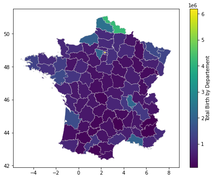

```python
import matplotlib.pyplot as plt
fig, ax = plt.subplots(1, figsize=(8, 6))

merged.plot(column="nombre",   ax=ax, linewidth=0.3,edgecolor="0.8",legend=True,legend_kwds
            ={"label": "Total Birth by Departement"})
```

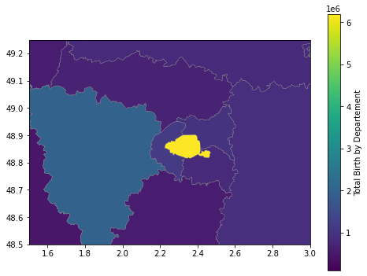

```python
# LET's ZOOM IN AND ADD A LEGEND
fig, ax = plt.subplots(1, figsize=(8, 6))
plt.axis([1.5,3,48.5,49.25])

merged.plot(column="nombre", ax=ax , linewidth=0.3, edgecolor="0.5", legend=True, legend_kwds
            ={"label": "Total Birth by Departement"})
```

```python
# POUR ALLER PLUS LOIN : https://geopandas.org/mapping.html
# https://geopandas.readthedocs.io/en/latest/docs/changelog.html
```

# 3. EXERCICES :

## - Display a choropleth map with Boys/girls total births disparity.

- you must ask yourself what is boys / girls disparity ?
- you must make sure your data is weighted:
  - if you use boys / girls ratio, you don't need to weight your data, because this ratio can be compared among all departement.
  - if you use boys - girls, you should then weight it using total births in the departement, and say for instance : difference between boys and girls births for 1000 births. if you don't do this weighting, your output will be meaningless, because it will mainly express the number of total births of the department.

## - Display a choropleth map with number of girls named Emma born in 2018

## - The same but weighted

( for instance nb of Emma births per thousand births in the dpt OR use dpt population ratio/ total france population) using a dataset with 2018 population for every dpt. the file must contain a department column with the same data as the prenoms dpt column...

SUPERBONUS

- choropleth map for the most innovant departements , population weighted what is innovation ?
- choropleth map for the most trendsetting departements , population weighted what is trendsetting ? we could detect firstname that appear (or come again..) in one or a few departments only, and then grows in other departments.

# Display a choropleth map with Boys/girls total births disparity

```python
#On prendra le rapport garcon/fille pour notre mesure de la disparité
df_disparity=pd.DataFrame()
df_disparity["nb_boys"]=prenoms[prenoms.sexe==1].groupby("dpt").nombre.sum()
df_disparity["nb_girls"]=prenoms[prenoms.sexe==2].groupby("dpt").nombre.sum()
df_disparity
```

| dpt | nb_boys | nb_girls |
| --- | --- | --- |
| 01 | 223592 | 216540 |
| 02 | 430054 | 415771 |
| 03 | 254648 | 245510 |
| 04 | 55387 | 50633 |
| 05 | 65511 | 61180 |
| ... | ... | ... |
| 971 | 339474 | 303637 |
| 972 | 334396 | 305431 |
| 973 | 94663 | 79971 |
| 974 | 617721 | 583845 |
| XX | 3779609 | 4685897 |

100 rows × 2 columns

```python
df_disparity=df_disparity.reset_index()
```

```python
df_disparity["disparity"]=df_disparity["nb_boys"]/df_disparity["nb_girls"]
```

```python
df_disparity
```

|  | dpt | nb_boys | nb_girls | disparity |
| --- | --- | --- | --- | --- |
| 0 | 01 | 223592 | 216540 | 1.032567 |
| 1 | 02 | 430054 | 415771 | 1.034353 |
| 2 | 03 | 254648 | 245510 | 1.037220 |
| 3 | 04 | 55387 | 50633 | 1.093891 |
| 4 | 05 | 65511 | 61180 | 1.070791 |
| ... | ... | ... | ... | ... |
| 95 | 971 | 339474 | 303637 | 1.118026 |
| 96 | 972 | 334396 | 305431 | 1.094833 |
| 97 | 973 | 94663 | 79971 | 1.183717 |
| 98 | 974 | 617721 | 583845 | 1.058022 |
| 99 | XX | 3779609 | 4685897 | 0.806592 |

100 rows × 4 columns

```python
#Faire test pour savoir si les départements correspondent aux nb_boys et nb_girls
```

```python
df_disparity["code_insee"]=df_disparity["dpt"]
df_disparity.head()
```

|  | dpt | nb_boys | nb_girls | disparity | code_insee |
| --- | --- | --- | --- | --- | --- |
| 0 | 01 | 223592 | 216540 | 1.032567 | 01 |
| 1 | 02 | 430054 | 415771 | 1.034353 | 02 |
| 2 | 03 | 254648 | 245510 | 1.037220 | 03 |
| 3 | 04 | 55387 | 50633 | 1.093891 | 04 |
| 4 | 05 | 65511 | 61180 | 1.070791 | 05 |

```python
map_df=map_df[map_df.code_insee.str.contains("\d\d\d")==False]
```

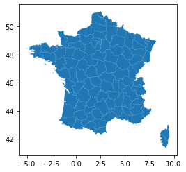

```python
map_df.plot()
```

```python
map_df.head()
```

|  | code_insee | nom | nuts3 | wikipedia | geometry |
| --- | --- | --- | --- | --- | --- |
| 0 | 01 | Ain | FR711 | b'fr:Ain (d\xe9partement)' | POLYGON ((5.25559 45.78459, 5.24813 45.78176, ... |
| 1 | 02 | Aisne | FR221 | b'fr:Aisne (d\xe9partement)' | POLYGON ((3.48175 48.86640, 3.48144 48.86635, ... |
| 2 | 03 | Allier | FR721 | b'fr:Allier (d\xe9partement)' | POLYGON ((2.38613 46.33196, 2.38597 46.33203, ... |
| 3 | 04 | Alpes-de-Haute-Provence | FR821 | fr:Alpes-de-Haute-Provence | POLYGON ((6.66579 43.83120, 6.66739 43.83119, ... |
| 4 | 05 | Hautes-Alpes | FR822 | fr:Hautes-Alpes | POLYGON ((6.24158 44.44686, 6.24210 44.44732, ... |

```python
merged = map_df.merge(df_disparity, on='code_insee')
merged.head()
```

|  | code_insee | nom | nuts3 | wikipedia | geometry | dpt | nb_boys | nb_girls | disparity |
| --- | --- | --- | --- | --- | --- | --- | --- | --- | --- |
| 0 | 01 | Ain | FR711 | b'fr:Ain (d\xe9partement)' | POLYGON ((5.25559 45.78459, 5.24813 45.78176, ... | 01 | 223592 | 216540 | 1.032567 |
| 1 | 02 | Aisne | FR221 | b'fr:Aisne (d\xe9partement)' | POLYGON ((3.48175 48.86640, 3.48144 48.86635, ... | 02 | 430054 | 415771 | 1.034353 |
| 2 | 03 | Allier | FR721 | b'fr:Allier (d\xe9partement)' | POLYGON ((2.38613 46.33196, 2.38597 46.33203, ... | 03 | 254648 | 245510 | 1.037220 |
| 3 | 04 | Alpes-de-Haute-Provence | FR821 | fr:Alpes-de-Haute-Provence | POLYGON ((6.66579 43.83120, 6.66739 43.83119, ... | 04 | 55387 | 50633 | 1.093891 |
| 4 | 05 | Hautes-Alpes | FR822 | fr:Hautes-Alpes | POLYGON ((6.24158 44.44686, 6.24210 44.44732, ... | 05 | 65511 | 61180 | 1.070791 |

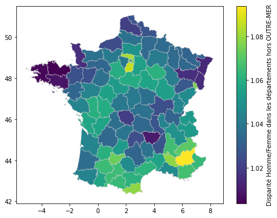

```python
import matplotlib.pyplot as plt
fig, ax = plt.subplots(1, figsize=(8, 6))

merged.plot(column="disparity",   ax=ax, linewidth=0.3,edgecolor="0.8",legend=True,legend_kwds
            ={"label": "Disparité Homme/Femme dans les départements hors OUTRE-MER"})
```

```python
#Conclusion:
```

[output not shown]

# Display a choropleth map with number of girls named Emma born in 2018

```python
df_Emma_2018=pd.DataFrame()
df_Emma_2018["nb_Emma"]=prenoms[(prenoms.preusuel=="EMMA") & (prenoms.annais=="2018")].groupby("dpt").nombre.sum()
df_Emma_2018
```

| dpt | nb_Emma |
| --- | --- |
| 01 | 37 |
| 02 | 38 |
| 03 | 28 |
| 04 | 6 |
| 05 | 10 |
| ... | ... |
| 95 | 79 |
| 971 | 17 |
| 972 | 11 |
| 973 | 11 |
| 974 | 43 |

98 rows × 1 columns

```python
df_Emma_2018=df_Emma_2018.reset_index()
df_Emma_2018
#On remarque qu'il manque un département surement il n'ya vait pas d'EMMA dans ce dpt en 2018
```

|  | dpt | nb_Emma |
| --- | --- | --- |
| 0 | 01 | 37 |
| 1 | 02 | 38 |
| 2 | 03 | 28 |
| 3 | 04 | 6 |
| 4 | 05 | 10 |
| ... | ... | ... |
| 93 | 95 | 79 |
| 94 | 971 | 17 |
| 95 | 972 | 11 |
| 96 | 973 | 11 |
| 97 | 974 | 43 |

98 rows × 2 columns

```python
df_Emma_2018["code_insee"]=df_Emma_2018["dpt"]
map_df=map_df[map_df.code_insee.str.contains("\d\d\d")==False]
merged = map_df.merge(df_Emma_2018, on='code_insee')
merged.head()
```

|  | code_insee | nom | nuts3 | wikipedia | geometry | dpt | nb_Emma |
| --- | --- | --- | --- | --- | --- | --- | --- |
| 0 | 01 | Ain | FR711 | b'fr:Ain (d\xe9partement)' | POLYGON ((5.25559 45.78459, 5.24813 45.78176, ... | 01 | 37 |
| 1 | 02 | Aisne | FR221 | b'fr:Aisne (d\xe9partement)' | POLYGON ((3.48175 48.86640, 3.48144 48.86635, ... | 02 | 38 |
| 2 | 03 | Allier | FR721 | b'fr:Allier (d\xe9partement)' | POLYGON ((2.38613 46.33196, 2.38597 46.33203, ... | 03 | 28 |
| 3 | 04 | Alpes-de-Haute-Provence | FR821 | fr:Alpes-de-Haute-Provence | POLYGON ((6.66579 43.83120, 6.66739 43.83119, ... | 04 | 6 |
| 4 | 05 | Hautes-Alpes | FR822 | fr:Hautes-Alpes | POLYGON ((6.24158 44.44686, 6.24210 44.44732, ... | 05 | 10 |

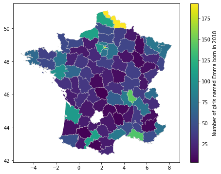

```python
import matplotlib.pyplot as plt
fig, ax = plt.subplots(1, figsize=(8, 6))

merged.plot(column="nb_Emma",   ax=ax, linewidth=0.3,edgecolor="0.8",legend=True,legend_kwds
            ={"label": "Number of girls named Emma born in 2018"})
#Région ou il n'y a pas d'EMMA représenté en blanc
```

# The same but weighted

```python
df_total_by_dpt=pd.DataFrame()
df_total_by_dpt["nb_total_2018_by_dpt"]=prenoms[prenoms.annais=="2018"].groupby("dpt").nombre.sum()
df_total_by_dpt=df_total_by_dpt.reset_index()
df_total_by_dpt
```

|  | dpt | nb_total_2018_by_dpt |
| --- | --- | --- |
| 0 | 01 | 2493 |
| 1 | 02 | 3289 |
| 2 | 03 | 1825 |
| 3 | 04 | 370 |
| 4 | 05 | 592 |
| ... | ... | ... |
| 94 | 95 | 15164 |
| 95 | 971 | 2543 |
| 96 | 972 | 2187 |
| 97 | 973 | 5618 |
| 98 | 974 | 10437 |

99 rows × 2 columns

```python
df_Emma_2018_weighted=df_Emma_2018.merge(df_total_by_dpt,on='dpt')
df_Emma_2018_weighted["nb_Emma_weighted"]=df_Emma_2018_weighted["nb_Emma"]/df_Emma_2018_weighted["nb_total_2018_by_dpt"]
df_Emma_2018_weighted
```

|  | dpt | nb_Emma | code_insee | nb_total_2018_by_dpt | nb_Emma_weighted |
| --- | --- | --- | --- | --- | --- |
| 0 | 01 | 37 | 01 | 2493 | 0.014842 |
| 1 | 02 | 38 | 02 | 3289 | 0.011554 |
| 2 | 03 | 28 | 03 | 1825 | 0.015342 |
| 3 | 04 | 6 | 04 | 370 | 0.016216 |
| 4 | 05 | 10 | 05 | 592 | 0.016892 |
| ... | ... | ... | ... | ... | ... |
| 93 | 95 | 79 | 95 | 15164 | 0.005210 |
| 94 | 971 | 17 | 971 | 2543 | 0.006685 |
| 95 | 972 | 11 | 972 | 2187 | 0.005030 |
| 96 | 973 | 11 | 973 | 5618 | 0.001958 |
| 97 | 974 | 43 | 974 | 10437 | 0.004120 |

98 rows × 5 columns

```python
merged2 = map_df.merge(df_Emma_2018_weighted, on='code_insee')
```

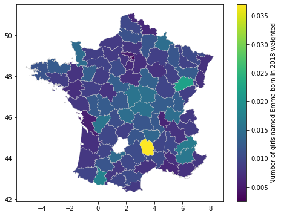

```python
import matplotlib.pyplot as plt
fig, ax = plt.subplots(1, figsize=(8, 6))

merged2.plot(column="nb_Emma_weighted",   ax=ax, linewidth=0.3,edgecolor="0.8",legend=True,legend_kwds
            ={"label": "Number of girls named Emma born in 2018 weighted"})
#On voit une amélioration de l'analyse qui aurait pu être mal interprété au premier graphe
```